# CITS4009-project2

### 4.5.4 SVM classifier

Because the SVM classifier can only be used to analyze numerical features, only numerical variables are used as model features in this classifier method[11].

```r
library(e1071)
svm_model <- svm(as.formula(paste("earning_class ~ ", paste(numeric_independent_variables, collapse = ' + '))), data = youtube_train, kernel = "radial")
```

Check the Model Performance

```r
# train set AUC score
svm_model_train_auc <- AUC_calculator(predict(svm_model, newdata=youtube_train), youtube_train[,target_column])
cat('svm_model\'s AUC score on the training set is',svm_model_train_auc, "\n")
```

```
## svm_model's AUC score on the training set is 0.9331285
```

```r
# test set AUC score
svm_model_test_auc <- AUC_calculator(predict(svm_model, newdata=youtube_test), youtube_test[,target_column])
cat('svm_model\'s AUC score on the testing set is',svm_model_test_auc)
```

```
## svm_model's AUC score on the testing set is 0.9040347
```

```r
# performance table
pretty_perf_table(svm_model,youtube_train[numeric_independent_variables],youtube_train[,target_column] == positive_label,youtube_test[numeric_independent_variables],youtube_test[,target_column] == positive_label)
```

```
##
##
## model                    precision   recall       f1   dev.norm
## ---------------------- ----------- -------- -------- ----------
## svm_model , training        0.9244   0.7237   0.8118     0.6529
## svm_model , testing         0.8214   0.6765   0.7419     0.5674
```

```r
# log likelihood
cat("svm_model Log Likelihood:", calculateLogLikelihood(svm_model, youtube_test, positive_label, epsilon = 1e-6), "\n")
```

```
## svm_model Log Likelihood: -1.312188
```

```r
cat("NULL model Log Likelihood:",logNull)
```

```
## NULL model Log Likelihood: -380.3058
```

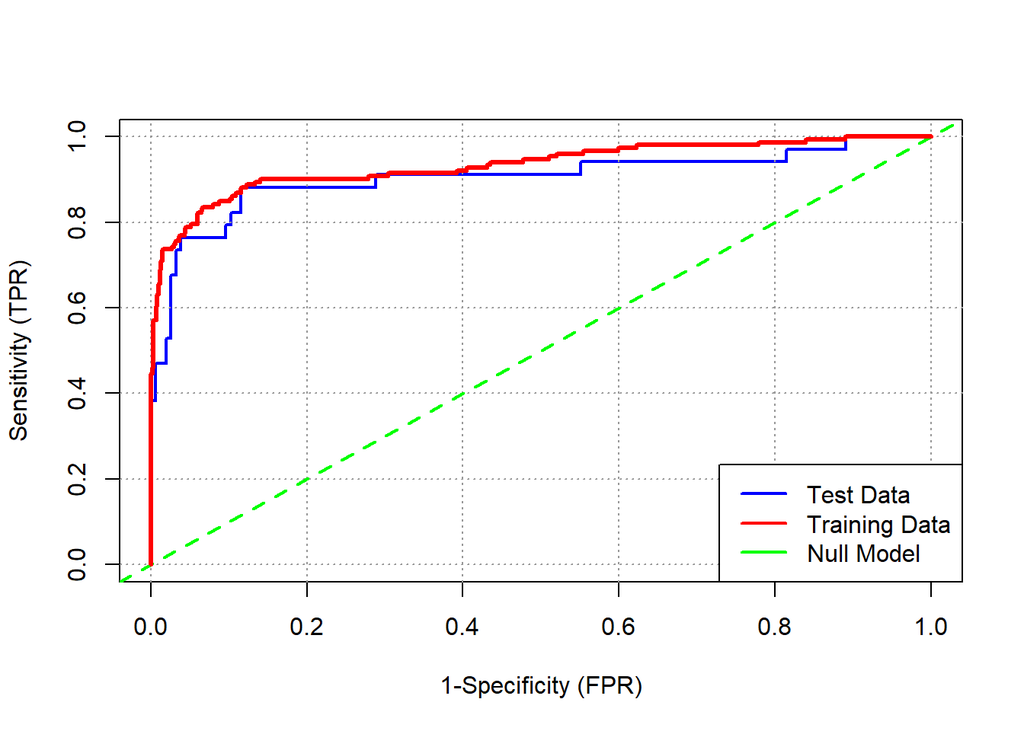

```r
# print ROC plot
pred_test_roc_svm_model <- predict(svm_model, newdata=youtube_test)
pred_train_roc_svm_model <- predict(svm_model, newdata=youtube_train)
plot_roc2(pred_test_roc_svm_model, youtube_test[[target_column]],
         pred_train_roc_svm_model, youtube_train[[target_column]])
```

The ‘SVM for all numeric features’ model displays a good ability to differentiate between classes with an AUC of 0.9331. While achieving a high precision of 0.9244, suggesting limited false positives, it has a moderate recall of 0.7237, indicating some potential for missing positive cases. The Log Likelihood value of -1.3122 is encouraging, outperforming the null model, though further refinement is needed. In summary, the model shows promise but requires optimization to balance precision and recall effectively and maximize its potential.